# Baseball Prediction

2 de janeiro de 2017

## Overview

This app uses data from the Joseph Adler data set. It comprises data from 2000 - 2008 for every major league baseball team, applies a linear model which predicts the number of runs scored by a team, and provide the prediction confidence interval based on some chosen variables.

A demo for the app can be found at: https://marcelotibau.shinyapps.io/baseball-prediction/.

Source code for ui.R and server.R files are available on the GitHub repo: https://github.com/marcelo-tibau/baseball-prediction

The inputs comprises of the following variables: Singles; Doubles; Triples;Home Runs; Walks; Hit by Pitch; Sacrifice Flies; Stolen Bases; and Caught Stealing.

The adjustment will impact on the number of runs scored and the resulting confidence interval.

## Residuals Vs Fitted

The residual data of a linear regression model is the difference between the observed data of the dependent variable y and the fitted values y. If we find equally spread residuals around a horizontal line without distinct patterns, it's a good indication that we don't have non-linear relationships.

## Residuals Vs Fitted (cont)

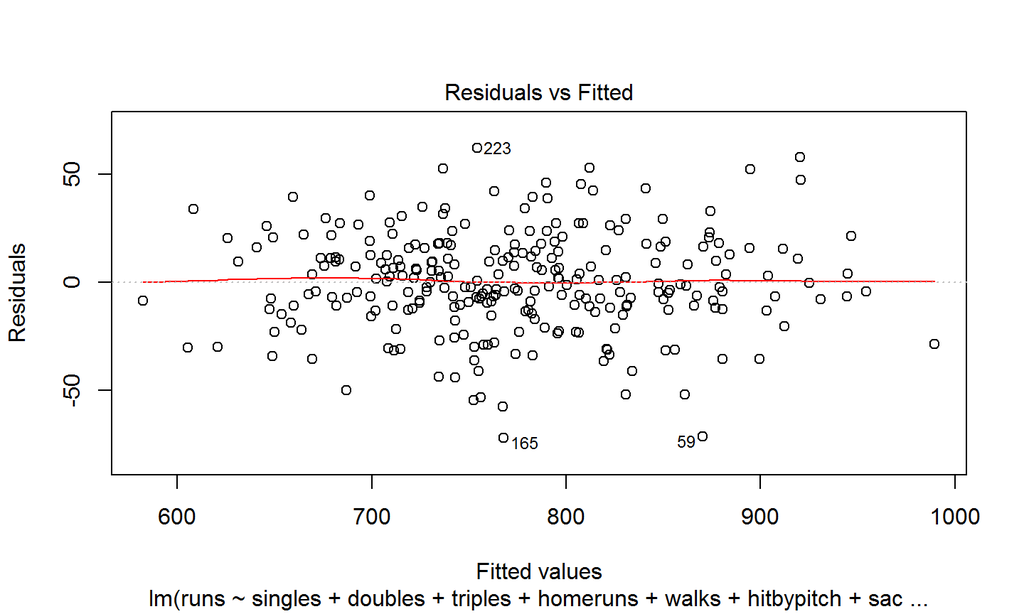

## Normal Q-Q

The Q-Q plot, or quantile-quantile plot, is a graphical tool to help us assess if a set of data plausibly came from some theoretical distribution such as a Normal or exponential. If both sets of quantiles came from the same distribution, we should see the points forming a line that's roughly straight.

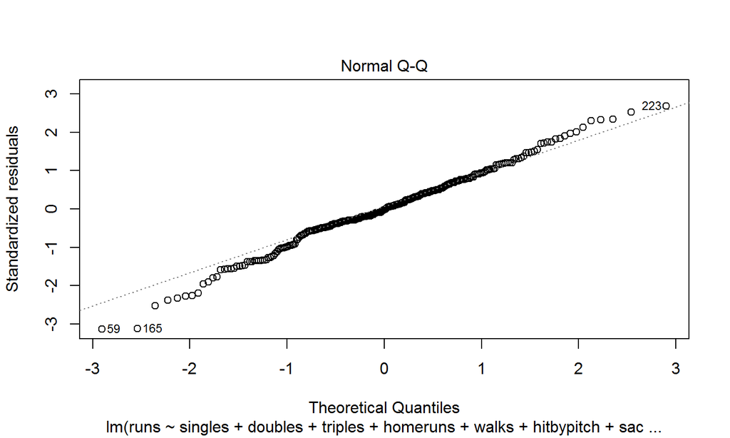